# Programa FinES.

#### 2° Cuatrimestre 2025.

Profesor: Daniel D. Molina

## ¡Bienvenidos/as!

Bienvenidos y bienvenidas a este espacio. En él encontrarán materiales, recursos y actividades para desarrollar la cursada de las asignaturas Metodología de la Investigación, Sociología y Derechos Humanos, correspondientes al segundo cuatrimestre del año 2025 del Programa FinES de la ciudad de Rauch.  
Les deseo el mayor de los éxitos y aprovecho para felicitarles por el inmenso esfuerzo que realizan.

Prof. Daniel D. Molina

## Breve guía práctica.

¿Cómo utilizar esta página?  
En esta página encontrarán unos botones con el nombre de las asignaturas que dicto en este cuatrimestre. Ustedes deben ingresar en la que corresponde a su curso y año y encontrarán distintos materiales y recursos que les permitirán conocer el detalle de la clase correspondiente, acceder al material de estudio y desarrollar actividades.  
Las actividaddes se entregarán en formato físico (papel) y de manera presencial durante las clases.  
Importante:  
Para aprobar la cursada es fundamental que cumplan con el requisito de asistencia del 80%. Tengan presente que son asignaturas con mucho trabajo en clase, que no puede ser reemplazado por la simple realización de trabajos prácticos.  
Por otra parte, es sumamente importante que respeten la puntualidad del inicio de clases y de finalización de las mismas.

**Metodología de la Investigación**

**Introducción**

Introducción a la Metodología de la Investigación  
La metodología de la investigación es el conjunto de procedimientos, técnicas y herramientas que permiten producir conocimiento de manera ordenada, crítica y fundamentada. En otras palabras, es el camino que seguimos para preguntarnos sobre un problema, buscar información, analizarla y llegar a conclusiones.

En el Programa Fines, aprender metodología de la investigación tiene un valor doble: Académico, porque permite desarrollar trabajos más organizados y fundamentados. Ciudadano y laboral, porque ayuda a analizar críticamente la realidad, tomar decisiones con base en evidencias y resolver problemas de la vida cotidiana.  
¿Qué significa investigar?  
Investigar no es solamente algo que hacen los científicos. Investigar es formular preguntas sobre la realidad y tratar de responderlas con información confiable.  
Ejemplos simples de la vida cotidiana:  
Comparar precios en distintos supermercados antes de comprar.  
Consultar opiniones de usuarios antes de elegir un celular.  
Revisar la historia de un hecho en Internet para comprenderlo mejor.  
En el ámbito académico, investigar supone:  
Identificar un problema o tema de interés.  
Formular una pregunta o hipótesis.  
Reunir datos a través de fuentes confiables (libros, entrevistas, encuestas, observaciones).  
Analizar esa información.  
Comunicar los resultados de manera clara.  
Etapas básicas de una investigación:  
Planteamiento del problema: definir qué queremos estudiar y por qué.  
Revisión de la bibliografía: consultar lo que otros autores ya han escrito sobre el tema.  
Formulación de objetivos y preguntas: qué buscamos responder.  
Elección del método: cuantitativo (números, encuestas, estadísticas), cualitativo (entrevistas, relatos, observaciones) o mixto.  
Recolección de datos: obtener la información.  
Análisis de los resultados: interpretar los datos y relacionarlos con la pregunta inicial.  
Conclusiones y comunicación: redactar un informe o presentación.  
Importancia para estudiantes del Plan Fines  
Desarrollar pensamiento crítico: cuestionar lo que se da por sentado.  
Tomar decisiones informadas: basarse en hechos, no en rumores.  
Fortalecer habilidades académicas: escribir, organizar ideas, argumentar.  
Conectar la escuela con la vida cotidiana y laboral: investigar problemáticas del barrio, del trabajo o de la comunidad.

**Clases**

En este apartado encontrarán las explicaciones correspondientes a los conceptos desarrollados en cada clase. También podrán ver actividades para realizar o indicaciones sobre aspectos generales de la clase.

**Clase 1. Revisión de introducción y saberes previos.**

En esta clase nos presentamos y hacemos un recorrido por las ideas que presentamos en la introducción.  
A continuación les dejo un link para acceder a un manual de metodología de la investigación. Se los dejo como material complementario por si llegaran a tener interés en profundizar algunas cuestiones.  
Manual de Introducción a la Metodología de la Investigación (PDF)

Y a continuación les dejo material de repaso de la primera clase para que lean y agreguen a sus registros de clase. Clase 1 (PDF)

**Clase 2. Sentido común vs. pensamiento crítico.**

## Ideas principales.

En el segundo encuentro comenzamos a desarrollar las principales diferencias entre el sentido común y el pensamiento crítico o racional.  
1. El sentido común en la vida cotidiana.  
El sentido común es un conjunto de creencias, saberes y explicaciones compartidas socialmente que permiten orientarnos en la vida diaria. Surge de la experiencia, la tradición y la transmisión cultural.  
Suelen ser respuestas rápidas, prácticas y aceptadas socialmente, pero no necesariamente verdaderas ni verificadas.  
En investigación, apoyarse solo en el sentido común puede llevar a reproducir prejuicios, estereotipos o explicaciones simplistas. Por ejemplo: “los jóvenes no se interesan por la política” puede sonar lógico desde el sentido común, pero requiere ser comprobado empíricamente para saber si es cierto y en qué condiciones.  
2. El pensamiento crítico en la investigación.  
El pensamiento crítico implica analizar, cuestionar y someter a evaluación rigurosa las ideas, datos y supuestos. En la metodología de la investigación, esto significa:  
No aceptar afirmaciones sin evidencia.  
Formular preguntas que vayan más allá de lo aparente.  
Contrastar hipótesis con datos empíricos.  
Revisar posibles sesgos en la observación o en la interpretación.  
El pensamiento crítico convierte al investigador en un sujeto activo que no se conforma con la “primera impresión” ni con lo que “todo el mundo dice”.

## Cuadro comparativo.

| Dimensión | Sentido Común | Pensamiento Crítico |
| --- | --- | --- |
| Origen | Experiencia cotidiana y tradición cultural. | Análisis reflexivo y sistemático. |
| Evidencia | Basado en creencias compartidas, no siempre comprobables. | Basado en pruebas empíricas y razonamiento lógico. |
| Función | Resolver problemas prácticos de la vida diaria. | Producir conocimiento confiable y argumentado. |
| Limitaciones | Puede reproducir prejuicios y errores. | Requiere esfuerzo, formación y apertura a la revisión. |
| Ejemplos | “Los pobres son pobres porque no trabajan lo suficiente.” | Indagar las causas estructurales de la pobreza mediante indicadores socioeconómicos. |

**Actividades**

En el siguiente vínculo encontrarán actividades para trabajar sobre sentido común y pensamiento crítico.Actividad n°1 (PDF)

## Videos.

Y a continuación, unos videos de YOUTUBE en dónde nos hablan del sentido común y el pensamiento crítico.

[Sentido común.](https://youtu.be/jGNjDqrq010?si=-Dk3PGITZFU0Lpip)  
[Pensamiento crítico.](https://youtu.be/3QJU7Ed0DZE?si=gyd3L8whEi-cBajK)

**Clase 3. Variables, tabulación, visualización.**

En el link que tienen a continuación se encuentra el material de la presente clase en formato PDF.  
Material de cursada (PDF)

**Clase 4. Práctica con encuesta propia.**

A continuación presentamos un ejemplo de recolección de datos, tabulación y visualización hecho a partir de una encuesta propia.  
[Enlace a la encuesta](https://consulta.shinyapps.io/encuesta-fines/)

# **Resultados:**

## Análisis.

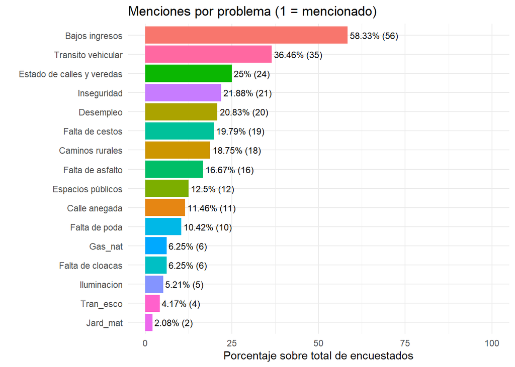

Distribución por sexo

| sexo | n | porcentaje |
| --- | --- | --- |
| Hombre | 21 | 21.9 |
| Mujer | 71 | 74.0 |
| NA | 4 | 4.2 |

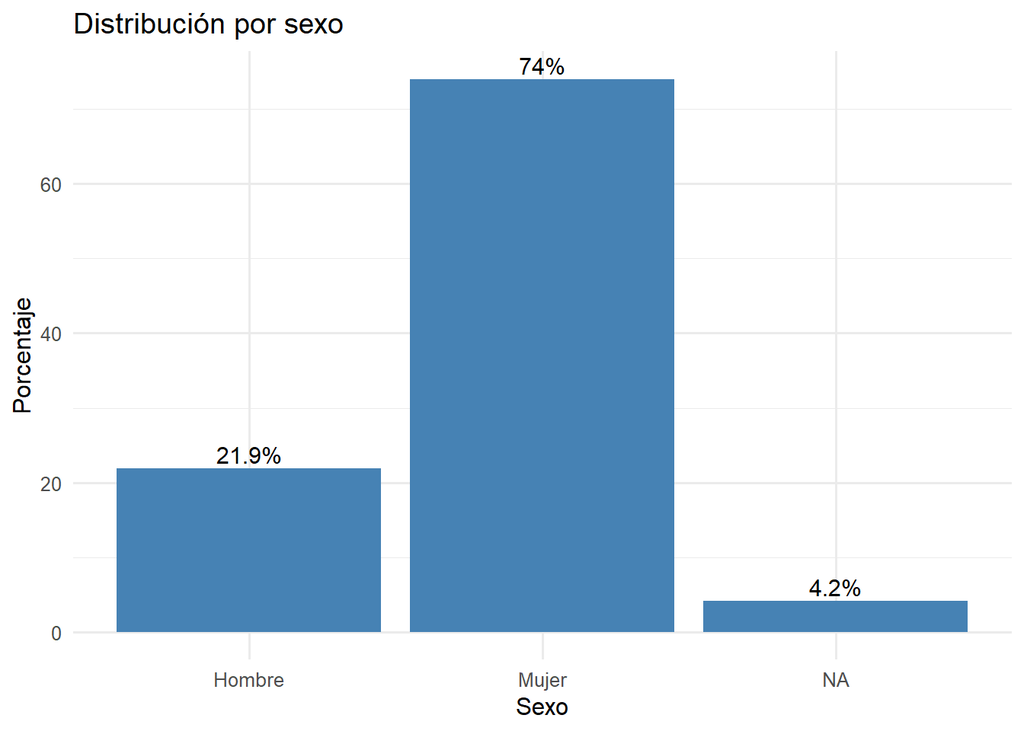

**Sociología**

**Introducción**

**¡Bienvenidas y bienvenidos!**

Bienvenidos/as a las clases de Sociología del segundo cuatrimestre correspondientes al primer año del Programa FinES de la ciudad de Rauch.En este apartado encontrarán las explicaciones correspondientes a los conceptos desarrollados en cada clase. También podrán ver actividades para realizar o indicaciones sobre aspectos generales de la clase.  
¡Buena suerte!

**Clases**

**Clase 1. Introducción al estudio de la Sociología.**

## Introducción a la Sociología.

La sociología es la ciencia que estudia la sociedad, sus estructuras, procesos y transformaciones. A diferencia del sentido común o de la experiencia personal, la sociología utiliza métodos científicos para comprender cómo las personas interactúan entre sí, cómo se organizan en grupos e instituciones, y cómo se generan cambios sociales.  
1. Objeto de estudio.  
El objeto central de la sociología es la vida social: las relaciones entre individuos y grupos, las normas que regulan la convivencia, los valores compartidos y los conflictos que emergen.  
Incluye fenómenos como:  
La familia y sus transformaciones.  
La educación y el sistema escolar.  
El trabajo y las organizaciones laborales.  
Los movimientos sociales y políticos.  
La desigualdad social y la estratificación.  
2. Surgimiento de la disciplina.  
La sociología nació en el siglo XIX, en un contexto de grandes transformaciones:  
Revolución Industrial:  
cambios en el trabajo, urbanización, aparición de nuevas clases sociales.  
Revolución Francesa:  
cuestionamiento del orden tradicional y surgimiento de la idea de ciudadanía.  
Expansión científica:  
búsqueda de aplicar métodos de las ciencias naturales al estudio de la sociedad.  
Los “padres fundadores” de la sociología fueron pensadores como:Auguste Comte: acuñó el término “sociología” y propuso estudiar la sociedad con base científica.Karl Marx:analizó la lucha de clases y el conflicto como motor de la historia.Émile Durkheim:investigó la cohesión social, las normas y fenómenos como el suicidio.Max Weber:estudió la acción social, la burocracia y el sentido subjetivo de las conductas.  
3. Perspectiva sociológica.  
Lo que distingue a la sociología es la capacidad de ver lo general en lo particular (cómo las experiencias individuales están influidas por estructuras sociales) y lo extraño en lo familiar (cuestionar prácticas cotidianas que damos por naturales).Por ejemplo: El hecho de ir a la escuela no depende solo de la decisión personal, sino de un sistema educativo con reglas, instituciones y políticas.  
Las modas, gustos musicales o consumos culturales no son únicamente elecciones libres, sino que están atravesados por factores sociales como clase, género, edad o territorio.  
4. Importancia de la sociología.  
Permite comprender mejor los problemas sociales (pobreza, violencia, desigualdad, discriminación).  
Brinda herramientas para analizar críticamente la realidad, sin quedarse en prejuicios o estereotipos.  
Contribuye a la formación ciudadana, fomentando una mirada reflexiva y responsable sobre la sociedad en la que vivimos.

**Clase 2. Conceptos básicos.**

## Conceptos básicos.

**Tema: Conceptos básicos de la sociología**  
1. Lectura inicial  
Para estudiar la sociedad, la sociología utiliza algunos conceptos que son clave para su desarrollo:  
Sociedad:  
conjunto de personas que conviven en un territorio, comparten instituciones, normas y valores.  
Cultura:  
todo lo que las personas crean y transmiten: costumbres, creencias, arte, conocimientos, lengua.  
Institución:estructuras sociales que organizan la vida colectiva (familia, escuela, Estado, iglesia).  
Norma:regla que guía la conducta. Puede ser formal (leyes, reglamentos) o informal (usos, costumbres).  
Rol:el “papel” que una persona cumple en la sociedad, asociado a expectativas (ejemplo: rol de estudiante, de docente, de hijo/a).

**Clase 3. Los grupos sociales, ciudadanía y derechos.**

# Introducción.

**Tema: Los grupos sociales, ciudadanía y derechos**  
En las clases anteriores vimos qué es la sociología y cómo estudia la sociedad. Ahora vamos a centrarnos en un concepto clave: los grupos sociales.  
La vida en sociedad se organiza en torno a **grupos,** y es dentro de ellos donde aprendemos **normas, valores, identidades y roles.** También analizaremos cómo esos grupos, en determinadas condiciones, pueden ser objeto de **exclusión social o vulneración de derechos,** lo que nos lleva a reflexionar sobre los dilemas actuales de la ciudadanía.

# ¿Qué son los grupos sociales?

Un **grupo social** es un conjunto de personas que interactúan entre sí, comparten objetivos, intereses, valores o normas, y se reconocen como parte de una unidad.  
**Características principales:**  
**Interacción:** existe comunicación e intercambio entre sus miembros.  
**Normas y valores compartidos:** pautas que regulan la conducta de los integrantes.  
**Identidad común:** sentimiento de pertenencia.  
**Estructura:** roles y jerarquías dentro del grupo.  
Ejemplos: La familia; un grupo de amigos, un sindicato; una organización barrial.

# Tipos de grupos sociales.

**Primarios:** relaciones afectivas cercanas y duraderas (ejemplo: familia, amigos íntimos).  
**Secundarios:** vínculos más formales y orientados a un objetivo (ejemplo: escuela, empresa, club).  
**De pertenencia:** aquellos a los que un individuo pertenece efectivamente.  
**De referencia:** aquellos con los que una persona se identifica, aunque no forme parte de ellos.

# Grupos sociales y ciudadanía.

La ciudadanía implica el reconocimiento de derechos (civiles, políticos, sociales y culturales) y la posibilidad de ejercerlos en igualdad de condiciones. Sin embargo, **no todos los grupos sociales acceden de la misma manera a esos derechos.** Factores como la **clase social, el género, la edad, la etnia o el lugar de residencia** pueden generar **desigualdades y vulneraciones** de derechos.  
**Ejemplos de vulneración:**  
Jóvenes sin acceso a educación de calidad.  
Mujeres sometidas a violencia de género.  
Comunidades indígenas con tierras en disputa.  
Personas migrantes con dificultades para acceder a servicios de salud.

# Eje problematizador.

**Actividades para resolver.**

**Actividades:**  
**Conceptual:** Definir con tus palabras qué es un grupo social y dar un ejemplo de cada tipo (primario, secundario, pertenencia, referencia).  
**Debate en grupo:** ¿Qué derechos son más vulnerados en tu comunidad? ¿Qué grupos sociales son los más afectados?  
**Ejercicio escrito:** Explicar cómo un grupo social puede convertirse en un actor de cambio para defender la ciudadanía (ejemplo: un movimiento feminista, un centro de estudiantes, una organización de derechos humanos).

**Clase 4. Vulneración de derechos de grupos sociales.**

# Introducción.

**Tema: Vulneración de derechos.**  
Hoy vamos a trabajar sobre los derechos y qué pasa cuando no se cumplen.  
En primer lugar, recordemos que los derechos humanos son aquellas garantías que tenemos todas las personas por el solo hecho de ser personas. *No dependen de la edad, el origen, la religión ni la clase social.*  
**Se dividen en distintos tipos:**  
*Derechos civiles:* nos protegen como individuos frente al Estado y frente a otros. Ejemplo: derecho a la vida, a la libertad, a la identidad, a la igualdad ante la ley.  
*Derechos políticos:* nos permiten participar en la vida pública y en las decisiones de un país. Ejemplo: derecho al voto, a ser elegido, a expresarse políticamente, a participar en organizaciones.  
*Derechos sociales:* buscan garantizar condiciones dignas de vida. Ejemplo: derecho a la educación, a la salud, al trabajo, a la vivienda, a la seguridad social.  
Ahora bien, en la realidad no siempre todas las personas pueden acceder de igual manera a estos derechos. A veces se ven limitados, negados o restringidos. A esto lo llamamos **vulneración de derechos.**  
Por ejemplo: Cuando un niño no puede ir a la escuela porque tiene que trabajar, se vulnera su derecho a la educación.  
Cuando a una mujer se le paga menos que a un varón por el mismo trabajo, se vulnera su derecho a la igualdad.  
Cuando una comunidad no tiene acceso a agua potable, se vulnera su derecho a una vida digna y a la salud.  
Estas situaciones no son casos aislados, sino que muchas veces afectan a grupos sociales enteros: pueblos originarios, migrantes, personas con discapacidad, sectores populares, entre otros.  
**Pregunta disparadora:**  
*Para abrir el debate con ustedes:*  
¿Alguna vez sintieron o vieron que a un grupo de personas no se le reconocieran sus derechos? (Pueden pensar en su barrio, en su lugar de trabajo, en noticias que hayan visto, o en su propia experiencia).

# Formas de vulneración de derechos

Cuando hablamos de vulneración de derechos nos referimos a las distintas maneras en que las personas o grupos sociales ven limitado o negado el acceso a aquello que por ley y dignidad les corresponde. Estas vulneraciones no siempre se dan de la misma manera.  
*Podemos reconocer, al menos, cuatro formas principales:*

## 1. Exclusión

Ocurre cuando se deja a un grupo fuera del acceso a bienes, servicios o instituciones.  
Ejemplo: cuando un barrio no tiene transporte público y sus habitantes no pueden llegar fácilmente a la escuela, al hospital o al trabajo.  
*También se da cuando ciertos sectores sociales quedan fuera del sistema educativo, sanitario o laboral.*

## 2. Discriminación

Se produce cuando a una persona o grupo se lo trata de manera desigual por características como su origen, género, edad, religión, orientación sexual, discapacidad o condición económica.  
Ejemplo: rechazar a alguien en un trabajo por ser migrante, por tener determinada apariencia física o por pertenecer a una minoría.  
*La discriminación muchas veces se basa en prejuicios y estereotipos que circulan en la sociedad.*

## 3. Desigualdad social

Es una forma de vulneración más estructural y profunda. Se manifiesta cuando distintos grupos tienen desiguales oportunidades de acceso a recursos como educación, salud, vivienda, trabajo digno.  
Ejemplo: la brecha de ingresos entre varones y mujeres, o entre trabajadores formales e informales.  
*La desigualdad social no siempre es visible en un hecho puntual, pero se traduce en diferencias persistentes en la calidad de vida.*

## 4. Violencia

Se presenta cuando se usan acciones físicas, psicológicas o simbólicas para limitar o anular los derechos de alguien.  
Ejemplo: la violencia de género que sufren muchas mujeres y diversidades, la violencia policial ejercida sobre jóvenes de sectores populares, o la violencia simbólica en los medios que ridiculizan a ciertos grupos.  
*La violencia no solo daña a nivel individual, sino que además refuerza desigualdades sociales.*

# Cierre

Estas cuatro formas de vulneración *—exclusión, discriminación, desigualdad social y violencia—* muchas veces se combinan. Por eso, cuando analizamos un caso concreto, podemos encontrar varias de ellas actuando al mismo tiempo.  
Ejemplo para pensar juntos/as: Una mujer migrante que trabaja en condiciones precarias puede estar siendo excluida de un trabajo formal, discriminada por su origen, atravesando desigualdad económica y expuesta a violencia laboral.

# Casos en Argentina: grupos sociales y vulneración de derechos.

En nuestro país, a pesar de los avances en leyes y políticas públicas, muchos grupos sociales siguen sufriendo dificultades para acceder plenamente a sus derechos. Veamos algunos ejemplos:

## 1. Pueblos originarios

*Situación:* muchas comunidades enfrentan problemas en el acceso a la tierra y al territorio, que son esenciales para su cultura y supervivencia.  
Ejemplo: conflictos por desalojos en comunidades del norte y sur del país (Salta, Formosa, Chubut).  
*Derecho vulnerado:* derecho a la tierra, a la identidad cultural, al ambiente sano.

## 2. Mujeres

*Situación:* a pesar de los avances en derechos (Ley de Matrimonio Igualitario, Ley de Interrupción Voluntaria del Embarazo, Ley de Paridad Política), las mujeres todavía sufren desigualdad.  
Ejemplo: brecha salarial (ganan en promedio menos que los varones por el mismo trabajo) y altos índices de violencia de género.  
*Derecho vulnerado:* derecho a la igualdad, al trabajo digno, a una vida libre de violencia.

## 3. Jóvenes

*Situación:* enfrentan dificultades para acceder al primer empleo y oportunidades educativas. También son estigmatizados por su forma de vestir o por vivir en determinados barrios.  
Ejemplo: jóvenes de sectores populares que son perseguidos por la policía bajo sospecha solo por su apariencia (“portación de rostro”).  
*Derecho vulnerado:* derecho al trabajo, a la educación, a la igualdad ante la ley.

## 4. Migrantes

*Situación:* a pesar de que la Constitución Nacional garantiza derechos a todas las personas que habitan el país, los migrantes suelen enfrentar discriminación y trabas burocráticas.  
<Ejemplo: dificultades en el acceso a la salud o la educación por no tener papeles en regla, o discursos que los responsabilizan de problemas sociales.  
*Derecho vulnerado:* derecho a la igualdad, a la salud, a la educación.

## 5. Población LGBTIQ+

*Situación:* Argentina es pionera en leyes de igualdad (Matrimonio Igualitario, Identidad de Género, Cupo Laboral Travesti-Trans), pero todavía existen situaciones de exclusión.  
Ejemplo: discriminación laboral hacia personas trans, que tienen altas tasas de desocupación y una expectativa de vida mucho menor que el promedio.  
*Derecho vulnerado:* derecho al trabajo, a la salud, a la vida digna, a la no discriminación.

## 6. Sectores populares

*Situación:* son los más afectados por la pobreza estructural, la falta de acceso a vivienda digna y servicios básicos.  
Ejemplo: familias que viven en barrios sin agua potable, cloacas ni transporte, lo que limita el acceso a salud y educación.  
*Derecho vulnerado:* derecho a la vivienda, a la salud, a la educación, a condiciones de vida dignas.

# Cierre.

Como vemos, cada *grupo* enfrenta formas particulares de vulneración, pero todos tienen en común la dificultad de acceder de manera plena a derechos que ya están reconocidos en la Constitución y en tratados internacionales.  
**Pregunta para debatir en clase:**  
*¿Qué creen que tienen en común estos casos? ¿Por qué algunos grupos son más vulnerables que otros?*

**Videos para ampliar:**  
Grupos Vulnerables y DD.HH. [Ver video en YouTube](https://youtu.be/qzHOhtRSXdI?si=J_WBV0-Ncllhz1dY)

En el siguiente vínculo encontrarán alos conceptos de la clase en formato pdf.Clase 4 (PDF)

**Derechos Humanos**

**Introducción**

**¿Qué son los Derechos Humanos?**  
**1. Introducción.**  
Los derechos humanos son un conjunto de derechos universales, inalienables y fundamentales que pertenecen a todas las personas por el solo hecho de serlo. Se basan en valores como la dignidad, la libertad, la igualdad y la justicia.  
Están reconocidos en documentos internacionales como la Declaración Universal de Derechos Humanos (1948) y en la Constitución Nacional Argentina.  
**2. Características principales.**  
**Universales:** corresponden a todas las personas, sin distinción de raza, sexo, religión, edad o nacionalidad.  
**Inalienables:** nadie puede quitarlos ni renunciar a ellos.  
**Indivisibles e interdependientes:** todos los derechos (civiles, políticos, económicos, sociales y culturales) están relacionados y tienen igual importancia.  
**Obligan al Estado:** los gobiernos deben respetarlos, protegerlos y garantizarlos.  
**3. Clasificación de los Derechos Humanos.**  
**Derechos civiles y políticos:** vida, libertad, igualdad ante la ley, participación política.  
**Derechos económicos, sociales y culturales:** educación, salud, trabajo digno, cultura.  
**Derechos colectivos o de solidaridad:** medio ambiente sano, paz, desarrollo de los pueblos.  
**4. Ejemplos cotidianos.**  
**Derecho a la educación:** poder asistir a la escuela sin discriminación.  
**Derecho a la salud:** acceso a hospitales y atención médica.  
**Derecho a la libertad de expresión:** poder opinar sin miedo a represalias.  
**Derecho al trabajo:** empleo en condiciones justas y dignas.  
**6. Cierre:**Los derechos humanos nos igualan a todos y son la base de la democracia.  
En las próximas clases se verá cómo se construyeron históricamente y qué luchas sociales hicieron posible su reconocimiento.

**Clase 1.¿Qué son los Derechos Humanos?**

**¿Qué son los Derechos Humanos?**  
**1. Para empezar.**  
Los derechos humanos son aquellas condiciones básicas que todas las personas necesitamos para vivir con dignidad. Nos pertenecen a todos, simplemente por el hecho de ser seres humanos.  
**2. Características principales.**  
**Universales:** los tienen todas las personas, sin importar quiénes sean ni dónde vivan.  
**Inalienables:** nadie puede quitárnoslos ni podemos renunciar a ellos.  
**Indivisibles:** todos son igual de importantes, no se pueden separar.  
**Protegidos por el Estado:** los gobiernos tienen la obligación de respetarlos y garantizar que se cumplan.  
**3. Tipos de derechos.**  
**Civiles y políticos:** derecho a la vida, a la libertad, a votar, a expresarse.  
**Económicos, sociales y culturales:** derecho a la educación, a la salud, al trabajo digno.  
**Colectivos o de solidaridad:** derecho a un ambiente sano, a la paz y al desarrollo.  
**4. Ejemplos cercanos.**  
**Asistir a la escuela sin discriminación.**  
**Poder recibir atención médica.**  
**Expresar tu opinión libremente.**  
**Tener un trabajo en condiciones justas.**  
**5. Actividades.**  
✏️ **Actividad 1 – Lluvia de ideas.**  
Escribí ejemplos de situaciones en las que se respetan derechos y otras en las que se vulneran.  
✏️ **Actividad 2 – Lectura y reflexión.**  
Leé este artículo de la Declaración Universal de Derechos Humanos (1948):  
**“Todos los seres humanos nacen libres e iguales en dignidad y derechos.”**  
**Preguntas para pensar:**  
¿Qué significa para vos la palabra dignidad?  
¿Por qué creés que se afirma que todos nacemos libres e iguales?  
✏️ **Actividad 3 – Debate en grupos.**  
En pequeños grupos, preparen un ejemplo real o imaginado que muestre:  
Un derecho humano respetado.  
Un derecho humano vulnerado.  
**6. Para cerrar.**  
Los derechos humanos son la base de la convivencia democrática. Gracias a ellos, todas las personas tenemos garantizadas condiciones mínimas de libertad, igualdad y justicia.

**Clase 2.Origen y evolución de los Derechos Humanos**

**1. Introducción.**  
En la clase anterior vimos qué son los derechos humanos y cuáles son sus características principales. En esta clase vamos a analizar cómo surgieron y cómo fueron evolucionando a lo largo de la historia hasta llegar al reconocimiento actual.  
**2. Antecedentes.** históricos.  
**Antigüedad:**  
En Grecia y Roma existían ideas de ciudadanía y leyes, pero no incluían a todos (esclavos y mujeres quedaban excluidos).  
**Edad Media:**  
Carta Magna (Inglaterra, 1215): limitó el poder del rey y reconoció derechos a los nobles.  
**3. Revoluciones y modernidad.**  
Revolución Gloriosa (1688, Inglaterra): origen de la Declaración de Derechos de 1689 → libertad de expresión en el Parlamento.  
Revolución de Independencia de EE.UU. (1776): Declaración de Independencia → **“Todos los hombres son creados iguales”.**  
Revolución Francesa (1789): Declaración de los Derechos del Hombre y del Ciudadano → igualdad ante la ley, soberanía popular.  
**4. Siglo XX y actualidad.**  
Segunda Guerra Mundial: los crímenes cometidos demostraron la necesidad de un acuerdo internacional.  
1948: Declaración Universal de los Derechos Humanos (ONU).  
Constitución Nacional Argentina: reconoce y protege derechos humanos en varios artículos, reforzados en la Reforma de 1994.  
**5. Actividades.**  
✏️ **Actividad 1 – Línea de tiempo.**  
En grupos, armen una línea de tiempo con los principales hitos históricos mencionados: 1215, 1689, 1776, 1789, 1948.  
✏️ **Actividad 2 – Lectura y análisis.**  
Fragmento de la Declaración de 1789:

**“Los hombres nacen y permanecen libres e iguales en derechos.”**

**Preguntas:**  
¿Qué relación tiene esta frase con lo que vimos en la Clase 1?  
¿A quiénes no incluía realmente esta declaración?  
✏️ **Actividad 3 – Debate.**  
¿Por qué creen que los derechos humanos no surgieron de una sola vez, sino que fueron el resultado de luchas sociales y políticas?  
**6. Cierre.**  
Los derechos humanos son el resultado de una larga historia de luchas, conquistas y acuerdos sociales.  
Hoy los entendemos como universales, pero esto fue posible gracias a que, en distintos momentos de la historia, personas y pueblos reclamaron por la libertad, la igualdad y la justicia.

Descargar PDF con material para ampliar

**Clase 3.Generaciones de Derechos y su vigencia en la actualidad.**

Descargar PDF con material para ampliar